# Analysis: engagement trajectories and dropout risk

What chain-structure adds to a 3-state engagement model

The bundled `trajectories` dataset records the weekly engagement state of 138 students across 15 weeks of a course. Three states: **Active**, **Average**, **Disengaged**. Some students have a *terminal-NA* pattern in the matrix — once their data goes missing, it stays missing — which we treat as **dropout**. This is the cleanest dataset in the package for `chain_structure()` because it admits two complementary chain models:

1. **Engagement-only chain** (3 states): how do students cycle between engagement levels? Regular, non-reversible — `markov_stability()`’s long-run distribution is interpretable.
2. **Augmented chain with Dropout as a fourth absorbing state**: how long until a student drops out, conditional on current engagement? The three engagement states are now **transient** and `markov_stability()` is *not* the right summary — `chain_structure()` is.

Both models are needed for a complete reading. Two functions in the package handle the wide-data plumbing:

- `actor_endpoints(data)` — tidy per-actor first/last state + dropout flag.
- `mark_terminal_state(data, state = "Dropout")` — fill terminal NAs with an explicit label so the resulting chain has the label as a structurally absorbing state.

## Setup

```r
ep <- actor_endpoints(trajectories)
kt(data.frame(
  metric = c("students", "weeks observed", "dropouts (terminal NA)",
             "completers"),
  value  = c(nrow(ep), ncol(trajectories),
             sum(ep$dropped_out), sum(!ep$dropped_out)),
  stringsAsFactors = FALSE
))
```

| metric | value |
| --- | --- |
| students | 138 |
| weeks observed | 15 |
| dropouts (terminal NA) | 18 |
| completers | 120 |

```r
kt(head(ep, 6),
   caption = "actor_endpoints() — first six rows")
```

actor_endpoints() — first six rows

| actor | first_state | last_state | first_step | last_step | n_observed | dropped_out |
| --- | --- | --- | --- | --- | --- | --- |
| 1 | Active | Active | 1 | 12 | 12 | TRUE |
| 2 | Average | Average | 1 | 15 | 15 | FALSE |
| 3 | Average | Active | 1 | 15 | 15 | FALSE |
| 4 | Active | Average | 1 | 15 | 15 | FALSE |
| 5 | Active | Average | 1 | 15 | 15 | FALSE |
| 6 | Average | Average | 1 | 15 | 15 | FALSE |

Each row records when the student entered the course (`first_step`, `first_state`), when they were last seen (`last_step`, `last_state`), and whether they dropped out (`last_step < 15` with all subsequent weeks NA).

## Part 1 — Engagement chain (no dropout)

`build_network()` on the raw matrix gives the engagement-only chain: the dynamics conditional on remaining in the course. NAs are skipped silently when transitions are counted.

```r
net_eng <- build_network(as.data.frame(trajectories), method = "relative")
cs_eng  <- chain_structure(net_eng)
summary(cs_eng)
```

| state | classification | period | persistence | return_probability | sojourn_steps | stationary_probability |
| --- | --- | --- | --- | --- | --- | --- |
| Active | recurrent | 1 | 0.6976 | 1 | 3.31 | 0.3719 |
| Average | recurrent | 1 | 0.6099 | 1 | 2.56 | 0.4431 |
| Disengaged | recurrent | 1 | 0.4831 | 1 | 1.93 | 0.1850 |

Reading the summary: the chain is **regular** (irreducible plus aperiodic), so `markov_stability()`’s stationary distribution is interpretable. **Disengaged is the least sticky state** (persistence ≈ 0.48, sojourn ≈ 1.93 weeks); Active is the stickiest (persistence ≈ 0.70, sojourn ≈ 3.31). All three states return to themselves with probability 1 (`return_probability` = 1 for recurrent states by definition).

Long-run mass: **~37% Active, ~44% Average, ~19% Disengaged**. Disengaged absorbs the smallest share of student-weeks.

```r
kt(round(net_eng$weights, 3),
   caption = "Engagement transition matrix (rows = this week, cols = next)")
```

Engagement transition matrix (rows = this week, cols = next)

| Active | Average | Disengaged |
| --- | --- | --- |
| 0.698 | 0.267 | 0.035 |
| 0.204 | 0.610 | 0.186 |
| 0.120 | 0.397 | 0.483 |

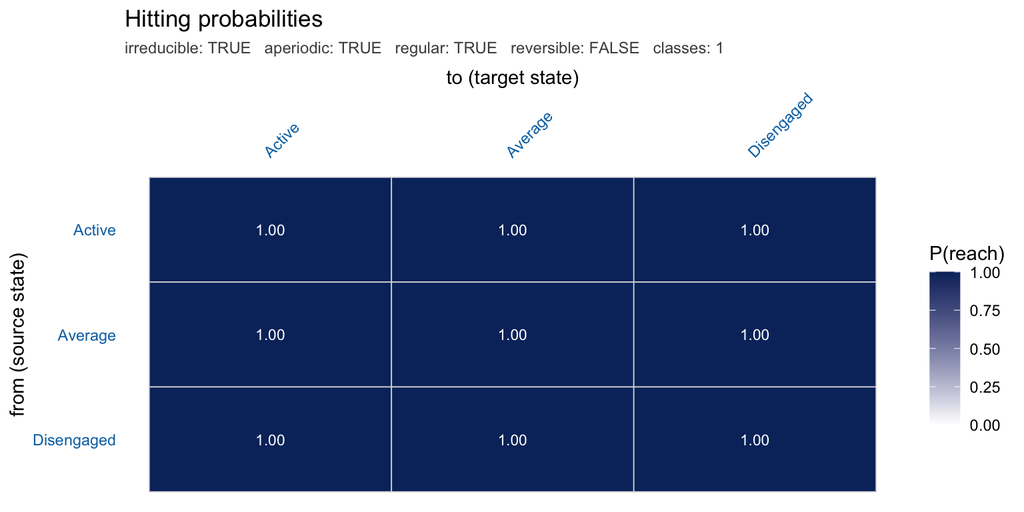

```r
plot(cs_eng)
```

## Part 2 — Augmented chain with Dropout

`mark_terminal_state(trajectories, state = "Dropout")` fills every terminal NA with the label `"Dropout"`. The resulting chain has Dropout as a structurally absorbing state.

```r
M_aug   <- mark_terminal_state(trajectories, state = "Dropout")
net_aug <- build_network(M_aug, method = "relative")
cs_aug  <- chain_structure(net_aug)
summary(cs_aug)
```

| state | classification | period | persistence | return_probability | sojourn_steps | absorption_probability | mean_absorption_time |
| --- | --- | --- | --- | --- | --- | --- | --- |
| Active | transient | NA | 0.6955 | 0.9745 | 3.28 | 1 | 101.01 |
| Average | transient | NA | 0.6050 | 0.9776 | 2.53 | 1 | 99.09 |
| Disengaged | transient | NA | 0.4687 | 0.9468 | 1.88 | 1 | 95.83 |
| Dropout | absorbing | 1 | 1.0000 | 1.0000 | Inf | NA | NA |

The summary now tells a different story:

- **`is_regular = FALSE`** — the chain is not regular because Dropout is absorbing. Running `markov_stability()` here would put all long-run mass on Dropout (correct as a limit, useless as a characterisation of student behaviour).
- **The three engagement states are classified `transient`**, and Dropout is `absorbing` with `period = 1` and infinite sojourn (once entered, never left).
- **`absorption_probability` is 1 for every transient state** — every student eventually drops out under this model. That follows from Dropout being the only absorbing state and every transient state having a positive path to it.
- **`mean_absorption_time` is what differs by starting state**.

```r
kt(round(net_aug$weights, 3),
   caption = "Augmented transition matrix (Dropout column = per-week dropout probability)")
```

Augmented transition matrix (Dropout column = per-week dropout probability)

| Active | Average | Disengaged | Dropout |
| --- | --- | --- | --- |
| 0.695 | 0.267 | 0.035 | 0.003 |
| 0.202 | 0.605 | 0.185 | 0.008 |
| 0.116 | 0.385 | 0.469 | 0.030 |
| 0.000 | 0.000 | 0.000 | 1.000 |

The Dropout column reads off the **per-week dropout probability** by current engagement state:

- **Active → Dropout: ~0.3% per week** (~1 in 333 student-weeks)
- **Average → Dropout: ~0.8% per week**
- **Disengaged → Dropout: ~3.0% per week** (~1 in 33 student-weeks)

Disengaged students drop out at **~10× the rate** of Active students. A single week of disengagement carries the immediate dropout risk of ten weeks of active engagement.

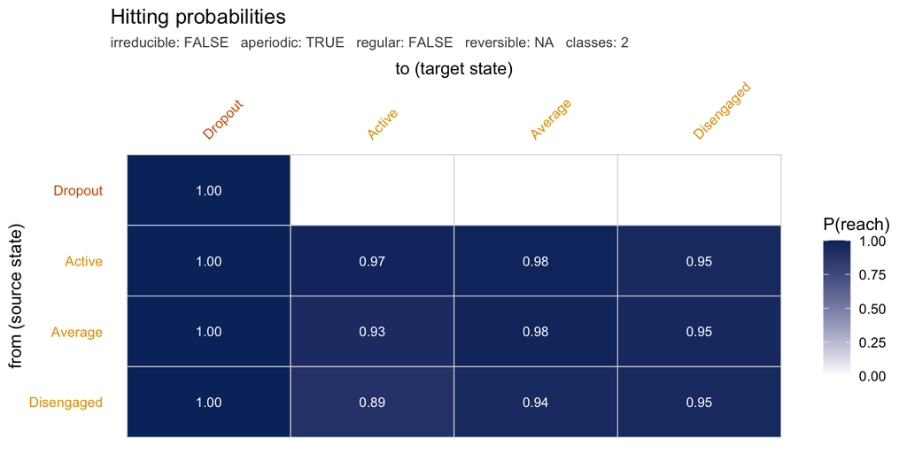

```r
plot(cs_aug)
```

Visually, the **Dropout column is solid dark** (every state reaches Dropout with probability 1) and the **Dropout row is white except in the Dropout column** (once dropped, no return). The asymmetry of that row vs column is the signature of an absorbing state.

### Why does starting state matter so little for absorption time?

The chain is *forgiving*. Even though Disengaged → Dropout per-week rate is 10× Active → Dropout, students mix between engagement states fast: from Disengaged, **52% are at Average or Active next week**. The bad-week-now disadvantage is diluted within one or two steps.

Mathematically, `mean_absorption_time` integrates over future trajectories, weighted by transition probabilities. A Disengaged student’s expected dropout time is **not** the inverse of the immediate dropout rate (1/0.030 ≈ 33 weeks); it is the equilibrium-mixture-weighted rate (~1/0.0104 ≈ 96 weeks). The chain absorbs the short-run rate ratio into a long-run rate that is much closer across starting states.

This is a general property of regular transient cores embedded in absorbing chains — the long-run absorption rate is closer to the stationary mixture rate than to any individual state’s per-step rate. `chain_structure()` makes both the immediate rates (visible in the augmented transition matrix) and the absorbed-by rates (in `mean_absorption_time`) visible side by side.

## Part 3 — Cross-tabulation: where were dropouts last seen?

The model-based view above has a model-free counterpart: simply cross-tabulate the per-actor `last_state` against the dropout flag.

```r
tab <- with(ep[!is.na(ep$last_state), ],
            table(last_state, dropped_out, dnn = c("last_state", "dropped_out")))
kt(data.frame(
  last_state  = rownames(tab),
  dropouts    = as.integer(tab[, "TRUE"]),
  completers  = as.integer(tab[, "FALSE"]),
  pct_dropout = sprintf("%.1f%%",
                        100 * tab[, "TRUE"] /
                              (tab[, "TRUE"] + tab[, "FALSE"])),
  stringsAsFactors = FALSE
))
```

| last_state | dropouts | completers | pct_dropout |
| --- | --- | --- | --- |
| Active | 2 | 43 | 4.4% |
| Average | 6 | 56 | 9.7% |
| Disengaged | 10 | 19 | 34.5% |

## When to use which

| Question | Right summary |
| --- | --- |
| Long-run engagement balance, ignoring dropout | `markov_stability()` on the engagement-only chain |
| Is the engagement chain regular? Does the stationary distribution exist? | `chain_structure()$is_regular` on the engagement-only chain |
| Per-week dropout probability by current state | `P[i, "Dropout"]` from `build_network(mark_terminal_state(data))` |
| Expected weeks to dropout from each state | `chain_structure()$mean_absorption_time` on the augmented chain |
| Probability of *eventual* dropout | `chain_structure()$absorption_probabilities` (= 1 here) |
| Per-actor first/last state and dropout flag | `actor_endpoints(data)` |
| Backwards check: where were the dropouts last seen? | Cross-tab `last_state` × `dropped_out` from `actor_endpoints()` |

The two chain models — engagement-only and engagement-plus-Dropout — are complementary. The first describes the dynamics of the *transient core*; the second embeds those dynamics in a funnel toward absorption. `chain_structure()` is the diagnostic that chooses the right summary: when an absorbing state is present, `markov_stability()` is uninterpretable and the absorption analysis takes its place.

## References

- Kemeny, J. G. and Snell, J. L. (1976). *Finite Markov Chains*. Springer-Verlag.
- Norris, J. R. (1997). *Markov Chains*. Cambridge University Press.
- Spedicato, G. A. (2017). Discrete Time Markov Chains with R. *R Journal* 9(2), 84–104.